# DACSS-603_Spring25:Homework 1

Author

Sangam Patil

# Importing Libraries

```r
library(tidyverse)
library(ggplot2)
```

## Question 1 : Use the LungCapData to answer the following questions. (Hint: Using dplyr, especially group_by() and summarize() can help you answer the following questions relatively efficiently.)

First, let’s download the LungCap.csv file and save it to your Quarto project folder. Read in the data file.

```r
df <- read.csv("LungCapData.csv")
```

## 3 Question 1 - a : What does the distribution of LungCap look like? (Hint: Plot a histogram with probability density on the y axis)

The distribution of LungCap looks as follows:

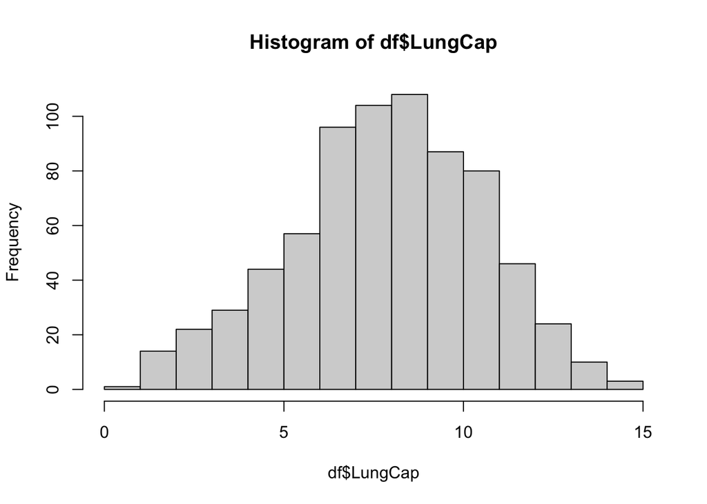

```r
hist(df$LungCap)
```

The histogram suggests that the distribution is close to a normal distribution. Most of the observations are close to the mean. Very few observations are close to the margins (0 and 15).

## Question 1 - b : Compare the probability distribution of the LungCap with respect to Males and Females? (Hint: make boxplots separated by gender using the boxplot() function)

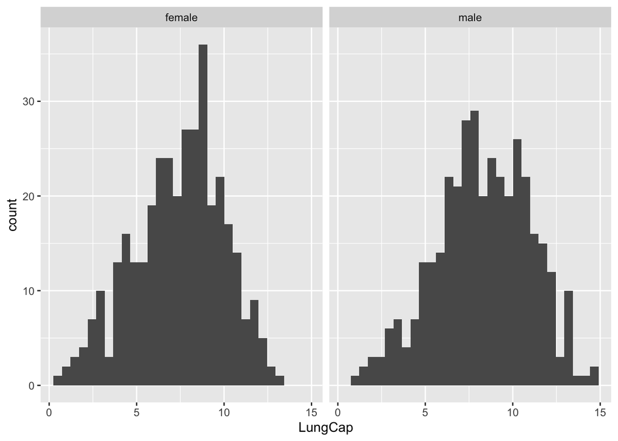

```r
ggplot(df, aes(x = LungCap)) +
  geom_histogram() +
  facet_wrap(~ Gender, nrow = 1)
```

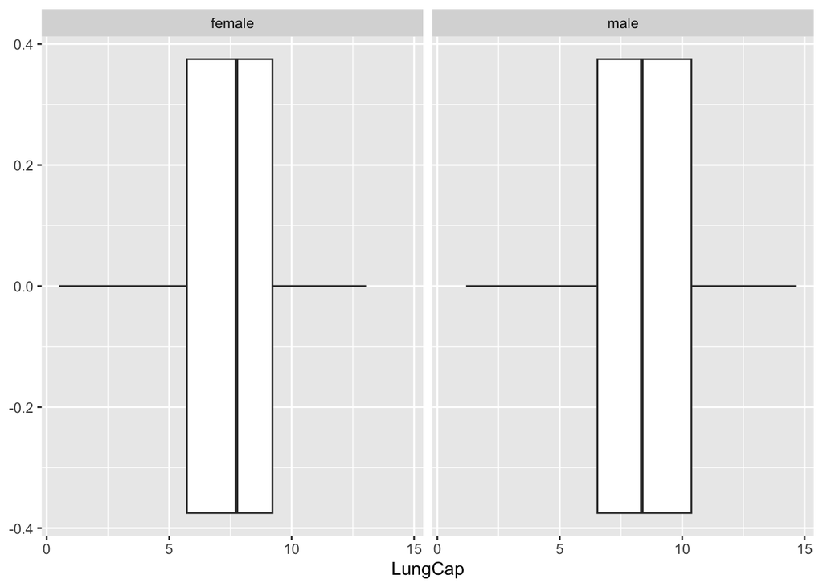

```r
ggplot(df, aes(x = LungCap)) +
  geom_boxplot() +
  facet_wrap(~ Gender, nrow = 1)
```

Both the histogram and bar plot suggests that, the distribution of ‘LungCap’ for ‘female’ is close to normal distribution with more observations close to mean and fewer observations far from mean. While the graphs of ‘LungCap’ for ‘male’ suggests that, distribution of the observations is more close to left skewed or negative skewed.

## Question 1 -c : Compare the mean lung capacities for smokers and non-smokers. Does it make sense?

```r
t_test_result <- t.test(LungCap ~ Smoke, data = df)
t_test_result
```

```
    Welch Two Sample t-test

data:  LungCap by Smoke
t = -3.6498, df = 117.72, p-value = 0.0003927
alternative hypothesis: true difference in means between group no and group yes is not equal to 0
95 percent confidence interval:
 -1.3501778 -0.4003548
sample estimates:
 mean in group no mean in group yes
         7.770188          8.645455
```

For my perspective, the data doesn’t make any sense. The fact that smoking damages the operation and the capacity of lungs, doesn’t seems to be valid for this data. In fact, this data proves that not smoking is dangerous to lungs(which is totally wrong). We should also consider that, the capacity of lungs is a natural thing and varies from person to person. There is a chance that even if a person does smoking still their lungs are not much affected by it. And, unluckily the randomize of the sampling have chosen those samples.

## Question 1 - d : Examine the relationship between Smoking and Lung Capacity within age groups: “less than or equal to 13”, “14 to 15”, “16 to 17”, and “greater than or equal to 18”.

```r
df = mutate(df, AgeCat = case_when(
  Age <= 13 ~ '<= 13',
  Age == 14 ~ '14 to 15',
  Age == 15 ~ '14 to 15',
  Age == 16 ~ '16 to 17',
  Age == 17 ~ '16 to 17',
  Age >= 18 ~ '>= 18'
))
```

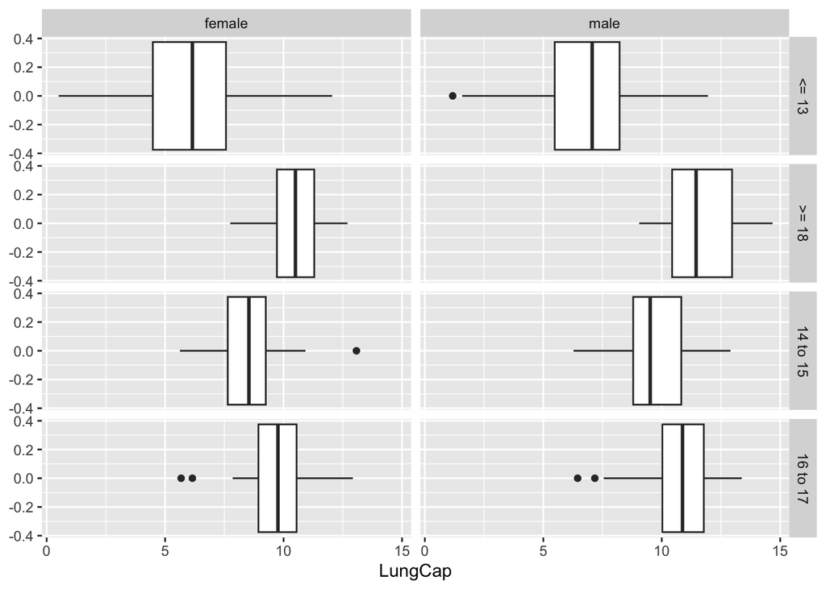

```r
ggplot(df, aes(x = LungCap)) +
  geom_boxplot() +
  facet_grid(AgeCat ~ Gender)
```

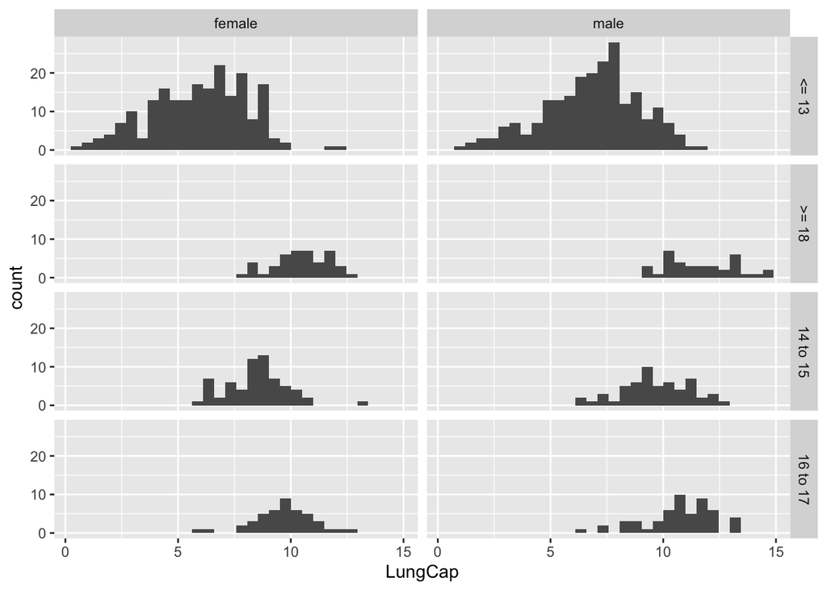

```r
ggplot(df, aes(x = LungCap)) +
  geom_histogram() +
  facet_grid(AgeCat ~ Gender)
```

For both males and females, the age group ‘<= 13’ shows the widest distribution of lung capacity, suggesting greater variability in this group. The age groups ‘14-15’, ‘16-17’, and ‘>= 18’, reveal a trend of decreasing lung capacity counts, particularly for females.  
Males, however, maintain a more consistent distribution across these older age groups, though with a slight decrease in the ‘>= 18’ group. Overall, the histograms suggest that lung capacity distribution is influenced by both age and gender, with younger individuals showing more variation and males demonstrating a more stable distribution across older age categories compared to females.

## Question 1 - e : Compare the lung capacities for smokers and non-smokers within each age group. Is your answer different from the one in part c. What could possibly be going on here?

```r
t_test_result <- t.test(LungCap ~ Smoke,
                        data = filter(df,
                                      AgeCat == '<= 13'))
t_test_result
```

```
    Welch Two Sample t-test

data:  LungCap by Smoke
t = -2.6091, df = 33.317, p-value = 0.01349
alternative hypothesis: true difference in means between group no and group yes is not equal to 0
95 percent confidence interval:
 -1.5003105 -0.1859019
sample estimates:
 mean in group no mean in group yes
         6.358746          7.201852
```

No, my answer for this age group is same as that in part c.

```r
t_test_result <- t.test(LungCap ~ Smoke,
                        data = filter(df,
                                      AgeCat == '14 to 15'))
t_test_result
```

```
    Welch Two Sample t-test

data:  LungCap by Smoke
t = 1.8648, df = 18.94, p-value = 0.07778
alternative hypothesis: true difference in means between group no and group yes is not equal to 0
95 percent confidence interval:
 -0.09162316  1.58590887
sample estimates:
 mean in group no mean in group yes
         9.138810          8.391667
```

```r
t_test_result <- t.test(LungCap ~ Smoke,
                        data = filter(df,
                                      AgeCat == '16 to 17'))
t_test_result
```

```
    Welch Two Sample t-test

data:  LungCap by Smoke
t = 3.1536, df = 33.545, p-value = 0.003392
alternative hypothesis: true difference in means between group no and group yes is not equal to 0
95 percent confidence interval:
 0.3858289 1.7862814
sample estimates:
 mean in group no mean in group yes
         10.46981           9.38375
```

```r
t_test_result <- t.test(LungCap ~ Smoke,
                        data = filter(df,
                                      AgeCat == '>= 18'))
t_test_result
```

```
    Welch Two Sample t-test

data:  LungCap by Smoke
t = 1.4766, df = 25.069, p-value = 0.1522
alternative hypothesis: true difference in means between group no and group yes is not equal to 0
95 percent confidence interval:
 -0.219197  1.330223
sample estimates:
 mean in group no mean in group yes
         11.06885          10.51333
```

I think it’s more possible that unluckily the randomize of the sampling have chosen wrong (not quantitatively or technically but qualitatively or we can say False-True) samples. Because there is a chance that even if a person does smoking still their lungs are not much affected by it and vice-versa.

## Question 2 : Let X = number of prior convictions for prisoners at a state prison at which there are 920 prisoners.

```r
data = data_frame(
  X = c(0,1,2,3,4),
  Frequency = c(150, 420, 180, 100, 70)
)
data
```

```
# A tibble: 5 × 2
      X Frequency
  <dbl>     <dbl>
1     0       150
2     1       420
3     2       180
4     3       100
5     4        70
```

## Question 2 - a : What is the probability that a randomly selected inmate has exactly 2 prior convictions?

```r
prob = data$Frequency[data$X == 2] / sum(data$Frequency)
print(paste('Probability of having exactly 2 orior convictions : ',prob))
```

```
[1] "Probability of having exactly 2 orior convictions :  0.195652173913043"
```

## Question 2 - b : What is the probability that a randomly selected inmate has fewer than 2 prior convictions?

```r
prob = sum(data$Frequency[data$X < 2]) / sum(data$Frequency)
print(paste('Probability of having fewer than 2 prior convictions : ',prob))
```

```
[1] "Probability of having fewer than 2 prior convictions :  0.619565217391304"
```

## Question 2 - c : What is the probability that a randomly selected inmate has 2 or fewer prior convictions?

```r
prob = sum(data$Frequency[data$X <= 2]) / sum(data$Frequency)
print(paste('Probability of having 2 or fewer convictions : ',prob))
```

```
[1] "Probability of having 2 or fewer convictions :  0.815217391304348"
```

## Question 2 - d : What is the probability that a randomly selected inmate has more than 2 prior convictions?

```r
prob = sum(data$Frequency[data$X > 2]) / sum(data$Frequency)
print(paste('Probability of having more than 2 prior convictions : ',prob))
```

```
[1] "Probability of having more than 2 prior convictions :  0.184782608695652"
```

## Question 2 - e : What is the expected value for the number of prior convictions?

```r
data$Probability <- data$Frequency / sum(data$Frequency)
expected_value <- sum(data$X * data$Probability)
print(paste('Expected value for number of prior convictions : ', expected_value))
```

```
[1] "Expected value for number of prior convictions :  1.47826086956522"
```

## Question 2 - f : Calculate the variance and the standard deviation for the Prior Convictions.

```r
variance <- sum((data$X - expected_value)^2 * data$Probability)
standard_deviation <- sqrt(variance)
print(paste("Variance of prior convictions : ", variance))
```

```
[1] "Variance of prior convictions :  1.24952741020794"
```

```r
print(paste("Standard Deviation of prior convictions : ", standard_deviation))
```

```
[1] "Standard Deviation of prior convictions :  1.11782262018978"
```